# Chapter 6

Alan T. Arnholt

Last compiled: January 06, 2022 at 09:45:09 AM

# 1 Scatterplots, Association, and Correlation

Objectives:

1. Examine scatterplots for association
2. Calculate the correlation coefficient
3. Properties of $r$
4. Introduce `tidyverse` (graphs, and data munging)

A **scatterplot** is a graph of points on a horizontal $x$-axis and vertical $y$-axis. It helps us picture associations between variables.

Typically, we will have an **explanatory** or predictor variable called $x$ and a **response** variable called $y$. These largely depend on how a problem is worded. What you might want to predict is $y$.

To describe a scatterplot, we discuss:

1. direction (positive or negative)
2. form (straight, curved, other)
3. strength (amount of scatter - strong, moderate, weak) and
4. outliers.

A numerical measure that gives us direction and strength of a linear relationship is correlation, $r = \frac{\sum{z_xz_y}}{n-1}$.

$$r = \frac{1}{n-1}\sum_{i=1}^{n}\left(\frac{x - \bar{x}}{s_x}\right)\left(\frac{y - \bar{y}}{s_y}\right)$$

Before we calculate correlation, we must check 3 things:

1. Quantitative variables?
2. Straight (cloud shape), no curve
3. No outliers

**Properties of $r$**

1. sign of $r$ gives direction of association
2. $-1 \leq r \leq 1$
3. $r_{x,y} = r_{y,x}$
4. Correlation has no units
5. Correlation is not affected by multiplying or shifting data
6. Correlation measures LINEAR association only
7. Outliers affect correlation greatly.

# 2 Scatterplots and the `tidyverse`

Read in the data set `Heights_and_weights.csv` stored in the `DATA` directory using the `read.csv()` function and store the results in `hw`.

```r
hw <- read.csv("./DATA/Heights_and_weights.csv")
head(hw) # shows first 6 rows of hw
```

```
  Weight Height
1    110     64
2    123     63
3    110     64
4    134     71
5    129     64
6    129     62
```

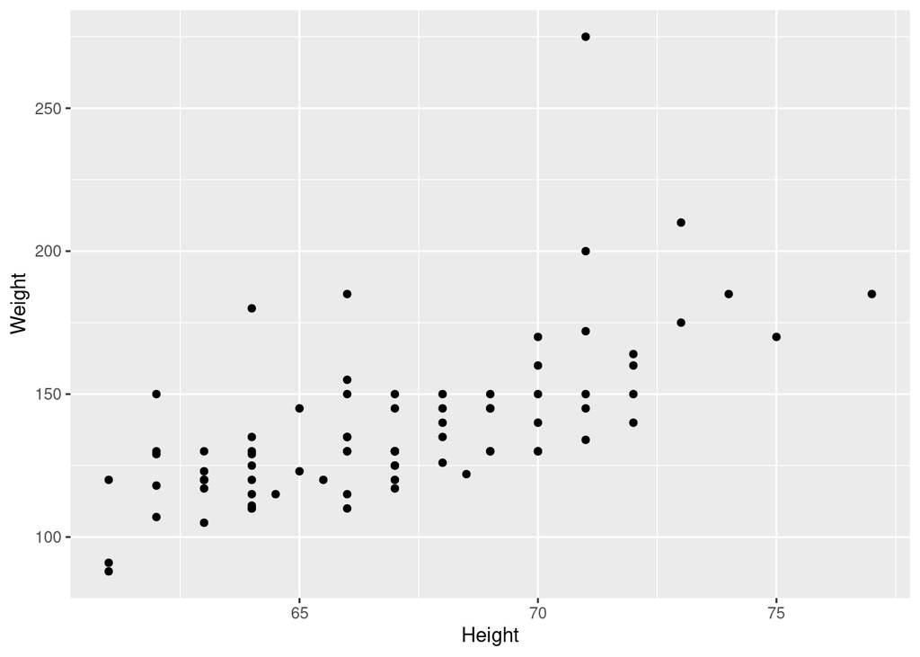

```r
library(tidyverse) # loads many useful packages including ggplot2 and dplyr
p <- ggplot(data = hw, aes(x = Height, y = Weight)) +
  geom_point()
#
p
```

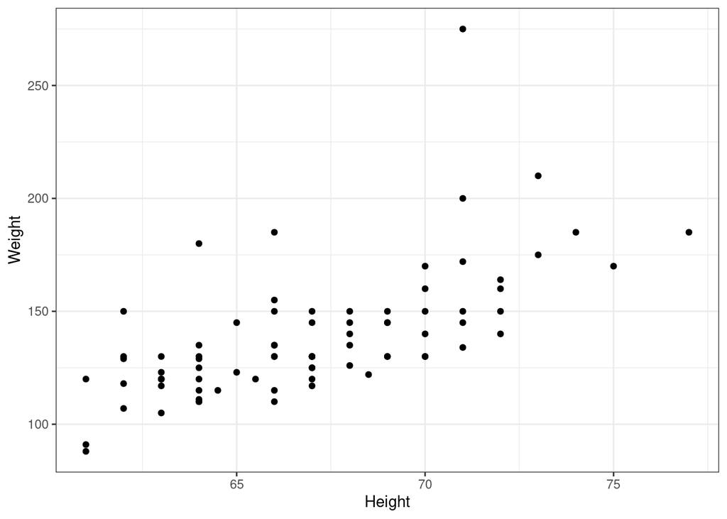

```r
p + theme_bw()
```

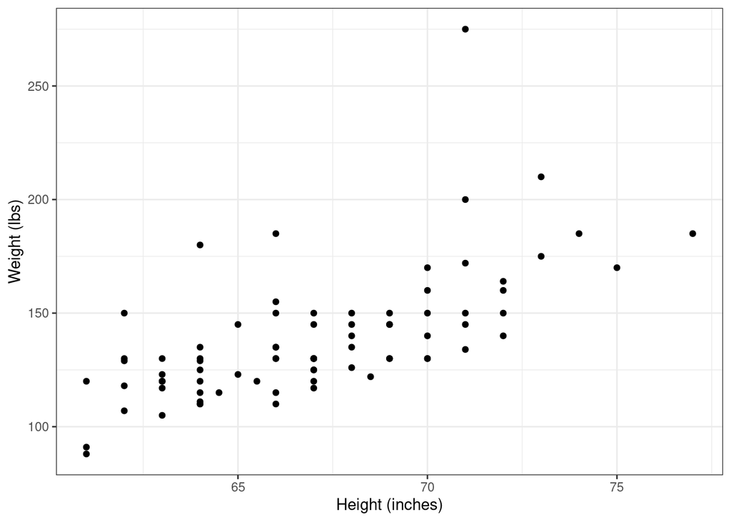

```r
p + theme_bw() + labs(x = "Height (inches)", y = "Weight (lbs)")
```

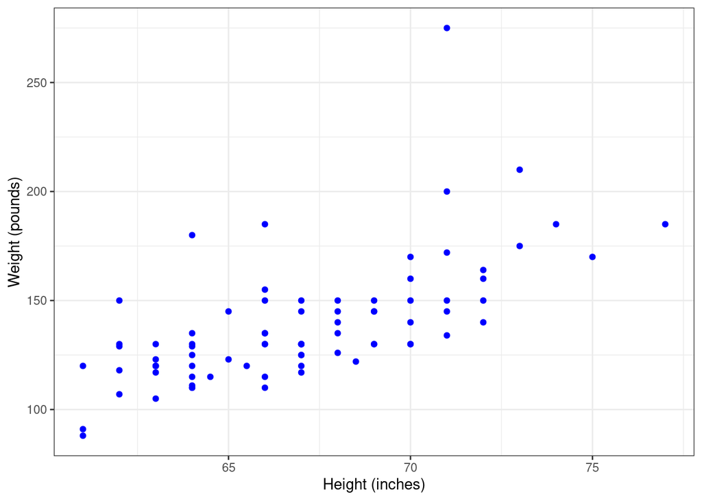

Figure 2.1: Scatterplot of Weight (pounds) versus Height (inches)

```r
p3 <- ggplot(data = hw, aes(x = Height, y = Weight)) +
  geom_point(color = "blue") +
  theme_bw() +
  labs(x = "Height (inches)", y = "Weight (pounds)")
p3
```

## 2.1 Using `mutate()`

Use `mutate()` to create a weight variable in kg, and a height variable in cm.

```r
hw <- hw %>%
  mutate(Weight_kg = Weight*0.453592, Height_cm = Height*2.54)
head(hw)
```

```
  Weight Height Weight_kg Height_cm
1    110     64  49.89512    162.56
2    123     63  55.79182    160.02
3    110     64  49.89512    162.56
4    134     71  60.78133    180.34
5    129     64  58.51337    162.56
6    129     62  58.51337    157.48
```

Create a scatterplot similar to Figure 2.1 using `Weight_kg` and `Height_cm` on the $y$ and $x$ axes instead of `Weight` and `Height`.

```r
# Your code goes here
```

Use `mutate()` to create `zx` and `zy` as well as the variable `CC` to indicate whether the product of `zx` times `zy` is positive or negative.

```r
hw <- hw %>%
  mutate(zx = (Height - mean(Height))/sd(Height), zy = (Weight - mean(Weight))/sd(Weight),
         CC = ifelse(abs(zx*zy) <.01, "neutral", ifelse(zx*zy > 0, "positive", "negative")))
head(hw)
```

```
  Weight Height Weight_kg Height_cm         zx         zy       CC
1    110     64  49.89512    162.56 -0.8251236 -1.0286871 positive
2    123     63  55.79182    160.02 -1.1030600 -0.5627313 positive
3    110     64  49.89512    162.56 -0.8251236 -1.0286871 positive
4    134     71  60.78133    180.34  1.1204310 -0.1684610 negative
5    129     64  58.51337    162.56 -0.8251236 -0.3476747 positive
6    129     62  58.51337    157.48 -1.3809964 -0.3476747 positive
```

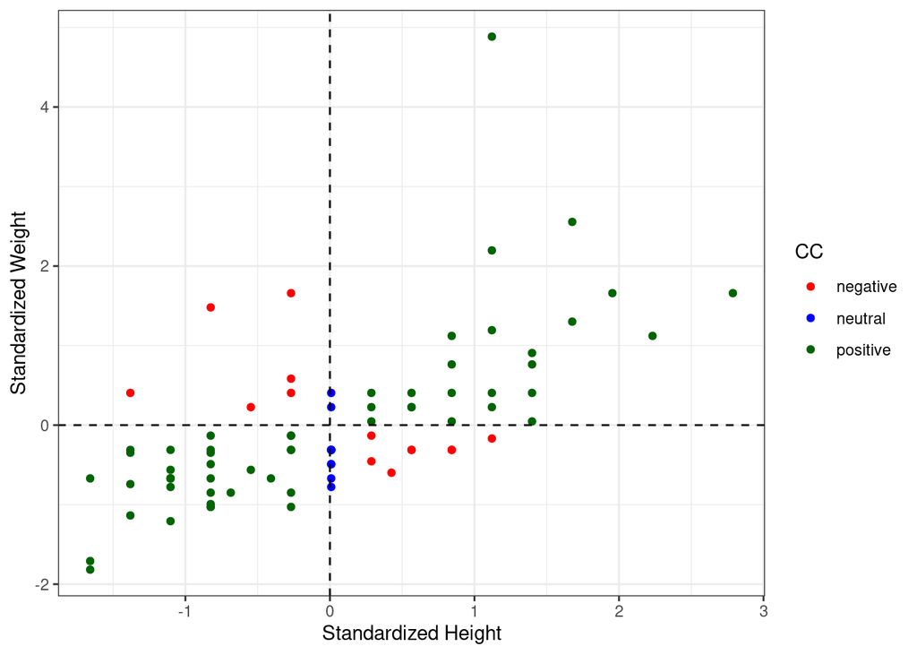

```r
ggplot(data = hw, aes(x = zx, y = zy, color = CC)) +
  geom_point() +
  geom_hline(yintercept = 0, lty = "dashed") +
  geom_vline(xintercept = 0, lty = "dashed") +
  theme_bw()+
  labs(x = "Standardized Height", y = "Standardized Weight") +
  scale_color_manual(values= c("red", "blue", "darkgreen"))
```

## 2.2 Computing the correlation

Compute the correlation between `Weight` and `Height` using the information in `hw`.

```r
head(hw)
```

```
  Weight Height Weight_kg Height_cm         zx         zy       CC
1    110     64  49.89512    162.56 -0.8251236 -1.0286871 positive
2    123     63  55.79182    160.02 -1.1030600 -0.5627313 positive
3    110     64  49.89512    162.56 -0.8251236 -1.0286871 positive
4    134     71  60.78133    180.34  1.1204310 -0.1684610 negative
5    129     64  58.51337    162.56 -0.8251236 -0.3476747 positive
6    129     62  58.51337    157.48 -1.3809964 -0.3476747 positive
```

```r
# Using tidyverse
hw %>%
  summarize(r_US = cor(Height, Weight), r_EU = cor(Height_cm, Weight_kg))
```

```
       r_US      r_EU
1 0.6440311 0.6440311
```

```r
# Using base R
cor(hw$Weight, hw$Height)
```

```
[1] 0.6440311
```

## 2.3 Straightening Scatterplots

Read in the data in `F-stops.csv` and create a scatterplot to resemble Figure 6.11 on page 183 from the text book.

```r
# Your Code Goes Here
```

Recreate Figure 6.13 on page 185 of the text.

```r
# Your Code Goes Here
```

Compute the correlation for the variables used in Figure 6.11 and Figure 6.13 of the text book.

```r
# Your Code Goes Here
```

# 3 Reading in data from homework/Pearson — One way to do it

1. Click open in Excel and the data will download in an `*.xlsx` format in your downloads folder.
2. Upload the `*.xslx` file to a `HWK_DATA` directory by clicking `upload` and navigating to the file you want to upload.

```r
library(readxl)
prob1 <- read_xlsx("./HWK_DATA/prob1.xlsx")
knitr::kable(prob1)
```

| Number_of_Sales_People_Working | Sales_in_Thousands |
| --- | --- |
| 5 | 11 |
| 8 | 16 |
| 13 | 16 |
| 13 | 18 |
| 14 | 21 |
| 16 | 21 |
| 16 | 22 |
| 16 | 24 |
| 18 | 25 |
| 19 | 26 |

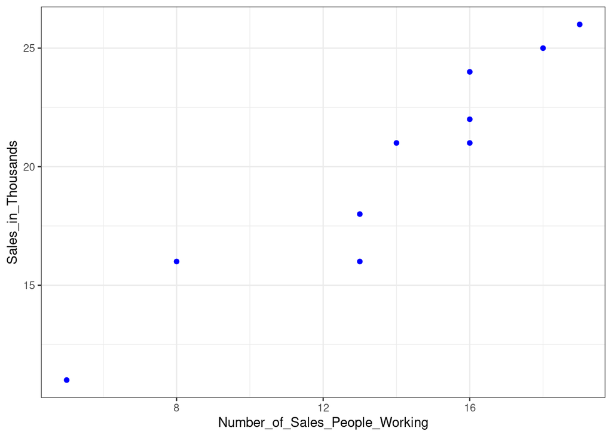

```r
ggplot(data = prob1, aes(x = Number_of_Sales_People_Working,
                         y = Sales_in_Thousands)) +
  geom_point(color = "blue") +
  theme_bw()
```

## Problem 15

```r
library(readxl)
prob15 <- read_xlsx("./HWK_DATA/prob15.xlsx")
knitr::kable(prob15)
```

| Planet | Position Number | Distance from star (million miles) |
| --- | --- | --- |
| A | 1 | 40 |
| B | 2 | 75 |
| C | 3 | 81 |
| D | 4 | 142 |
| E | 5 | 484 |
| F | 6 | 902 |
| G | 7 | 1798 |
| H | 8 | 2807 |
| J | 9 | 3666 |

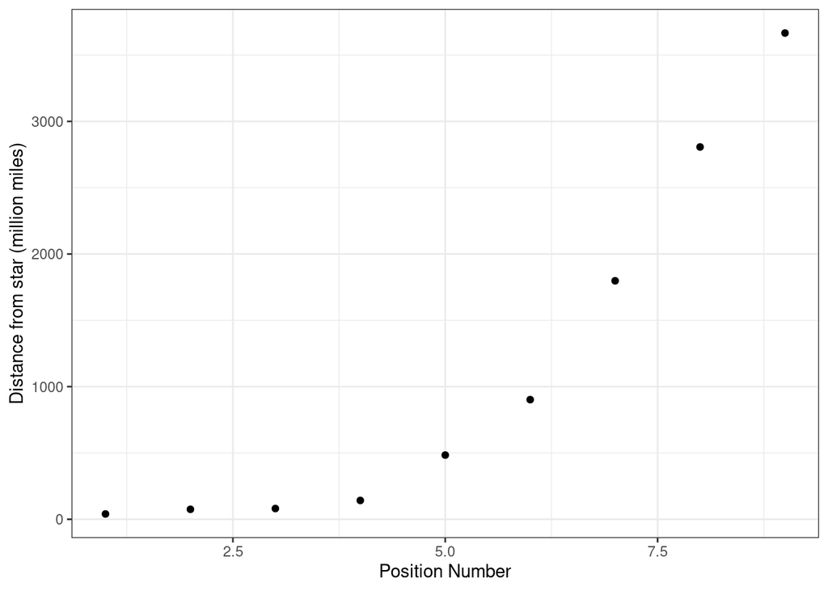

```r
ggplot(data = prob15, aes(x = `Position Number`, y = `Distance from star (million miles)`)) +
  geom_point() +
  theme_bw()
```